# Independent Project Week 13

Roselynn

1/15/2021

# 1. Problem Statement

### 1.1.Defining the Question

Characterize the behavior of the Kira Plastinina brand customers using unsupervised learning techniques and provide recommendations and insights to the company based on my findings.

### 1.2.Metric for Success

To build a model that can accurately characterize the customers behavior and to relay my findings based on the results of my model.

### 1.3. The Context

Kira Plastinina is a Brand of Fashionable Designer clothes marketed primarily to young women and sold across several countries namely Russia, Ukraine, Kazakhstan, Belarus, China, Philippines, and Armenia. The brand’s Sales and Marketing team would like to understand their customer’s behavior from data that they have collected over the past year. More specifically, they would like to learn the characteristics of customer groups. Therefore as the researcher I am tasked with analyzing the data and providing insights and recommendations to the company based on my findings.

### 1.4.The Experimental Design Taken

I carried out my analysis gradually ,starting with the problem statement , I then imported the dataset and performed data cleaning , I then carried out my EDA and built my model , finally after doing so I challenged my solution and then finished with providing recommendations based on the findings of my analysis.

# 2.Data Sourcing

The data was provided by the company’s Sales and Marketing team and can be found at this [link](http://bit.ly/EcommerceCustomersDataset). The description of the dataset and its columns is provided within this document.

### 2.1. The Appropriateness of the Data

Given the problem at hand , the data provided was accurate and adequate enough for me to carry out my analysis.

# 3. Check the Data

I imported the dataset and loaded the libraries that I used for my analysis.

```r
#Loading the Libraries used in this analysis

library(tidyverse) # collection of R packages for preparing, wrangling and visualizing data.
library(ggpubr)
```

I then undertook several steps to check the data and its attributes , highlighting each step throughout the whole process.

```r
#Importing the Dataset
online_shoppers <- read_csv("C:/Users/Njeri/Downloads/online_shoppers_intention.csv")
```

After importing the dataset I used the glimpse() function to preview my dataset

```r
# Obtaining information about the dataset
glimpse(online_shoppers)
```

```
## Rows: 12,330
## Columns: 18
## $ Administrative          <dbl> 0, 0, 0, 0, 0, 0, 0, 1, 0, 0, 0, 0, 0, 0, 0...
## $ Administrative_Duration <dbl> 0, 0, -1, 0, 0, 0, -1, -1, 0, 0, 0, 0, 0, 0...
## $ Informational           <dbl> 0, 0, 0, 0, 0, 0, 0, 0, 0, 0, 0, 0, 0, 0, 0...
## $ Informational_Duration  <dbl> 0, 0, -1, 0, 0, 0, -1, -1, 0, 0, 0, 0, 0, 0...
## $ ProductRelated          <dbl> 1, 2, 1, 2, 10, 19, 1, 1, 2, 3, 3, 16, 7, 6...
## $ ProductRelated_Duration <dbl> 0.000000, 64.000000, -1.000000, 2.666667, 6...
## $ BounceRates             <dbl> 0.200000000, 0.000000000, 0.200000000, 0.05...
## $ ExitRates               <dbl> 0.200000000, 0.100000000, 0.200000000, 0.14...
## $ PageValues              <dbl> 0, 0, 0, 0, 0, 0, 0, 0, 0, 0, 0, 0, 0, 0, 0...
## $ SpecialDay              <dbl> 0.0, 0.0, 0.0, 0.0, 0.0, 0.0, 0.4, 0.0, 0.8...
## $ Month                   <chr> "Feb", "Feb", "Feb", "Feb", "Feb", "Feb", "...
## $ OperatingSystems        <dbl> 1, 2, 4, 3, 3, 2, 2, 1, 2, 2, 1, 1, 1, 2, 3...
## $ Browser                 <dbl> 1, 2, 1, 2, 3, 2, 4, 2, 2, 4, 1, 1, 1, 5, 2...
## $ Region                  <dbl> 1, 1, 9, 2, 1, 1, 3, 1, 2, 1, 3, 4, 1, 1, 3...
## $ TrafficType             <dbl> 1, 2, 3, 4, 4, 3, 3, 5, 3, 2, 3, 3, 3, 3, 3...
## $ VisitorType             <chr> "Returning_Visitor", "Returning_Visitor", "...
## $ Weekend                 <lgl> FALSE, FALSE, FALSE, FALSE, TRUE, FALSE, FA...
## $ Revenue                 <lgl> FALSE, FALSE, FALSE, FALSE, FALSE, FALSE, F...
```

`The dataset had 18 columns and 12,330 rows the descriptions for these columns and the dataset in general is as listed below :

- The dataset consists of 10 numerical and 8 categorical attributes. The ‘Revenue’ attribute can be used as the class label.
- **Administrative**, **Administrative Duration**, **Informational**, **Informational Duration**, **Product Related** and **Product Related Duration** represents the number of different types of pages visited by the visitor in that session and total time spent in each of these page categories. The values of these features are derived from the URL information of the pages visited by the user and updated in real-time when a user takes an action, e.g. moving from one page to another.
- The **Bounce Rate**, **Exit Rate** and **Page Value** features represent the metrics measured by **Google Analytics** for each page in the e-commerce site.
- The value of the **Bounce Rate** feature for a web page refers to the percentage of visitors who enter the site from that page and then leave (**bounce**) without triggering any other requests to the analytics server during that session.
- The value of the **Exit Rate** feature for a specific web page is calculated as for all pageviews to the page, the percentage that was the last in the session.
- The **Page Value** feature represents the average value for a web page that a user visited before completing an e-commerce transaction.
- The **Special Day** feature indicates the closeness of the site visiting time to a specific special day (e.g. Mother’s Day, Valentine’s Day) in which the sessions are more likely to be finalized with the transaction. The value of this attribute is determined by considering the dynamics of e-commerce such as the duration between the order date and delivery date. For example, for Valentina’s day, this value takes a nonzero value between February 2 and February 12, zero before and after this date unless it is close to another special day, and its maximum value of 1 on February 8.
- The dataset also includes the operating system, browser, region, traffic type, visitor type as returning or new visitor, a Boolean value indicating whether the date of the visit is weekend, and month of the year.`

I then previewed the dataset itself in order to get a closer look using the head() function

```r
# Previewing the Dataset
head(online_shoppers)
```

```
## # A tibble: 6 x 18
##   Administrative Administrative_~ Informational Informational_D~ ProductRelated
##            <dbl>            <dbl>         <dbl>            <dbl>          <dbl>
## 1              0                0             0                0              1
## 2              0                0             0                0              2
## 3              0               -1             0               -1              1
## 4              0                0             0                0              2
## 5              0                0             0                0             10
## 6              0                0             0                0             19
## # ... with 13 more variables: ProductRelated_Duration <dbl>, BounceRates <dbl>,
## #   ExitRates <dbl>, PageValues <dbl>, SpecialDay <dbl>, Month <chr>,
## #   OperatingSystems <dbl>, Browser <dbl>, Region <dbl>, TrafficType <dbl>,
## #   VisitorType <chr>, Weekend <lgl>, Revenue <lgl>
```

I finally obtained the summary statistics with the summary() function.

```r
# Obtaining the Summary statistics of the dataset
summary(online_shoppers)
```

```
##  Administrative   Administrative_Duration Informational
##  Min.   : 0.000   Min.   :  -1.00         Min.   : 0.000
##  1st Qu.: 0.000   1st Qu.:   0.00         1st Qu.: 0.000
##  Median : 1.000   Median :   8.00         Median : 0.000
##  Mean   : 2.318   Mean   :  80.91         Mean   : 0.504
##  3rd Qu.: 4.000   3rd Qu.:  93.50         3rd Qu.: 0.000
##  Max.   :27.000   Max.   :3398.75         Max.   :24.000
##  NA's   :14       NA's   :14              NA's   :14
##  Informational_Duration ProductRelated   ProductRelated_Duration
##  Min.   :  -1.00        Min.   :  0.00   Min.   :   -1.0
##  1st Qu.:   0.00        1st Qu.:  7.00   1st Qu.:  185.0
##  Median :   0.00        Median : 18.00   Median :  599.8
##  Mean   :  34.51        Mean   : 31.76   Mean   : 1196.0
##  3rd Qu.:   0.00        3rd Qu.: 38.00   3rd Qu.: 1466.5
##  Max.   :2549.38        Max.   :705.00   Max.   :63973.5
##  NA's   :14             NA's   :14       NA's   :14
##   BounceRates         ExitRates         PageValues        SpecialDay
##  Min.   :0.000000   Min.   :0.00000   Min.   :  0.000   Min.   :0.00000
##  1st Qu.:0.000000   1st Qu.:0.01429   1st Qu.:  0.000   1st Qu.:0.00000
##  Median :0.003119   Median :0.02512   Median :  0.000   Median :0.00000
##  Mean   :0.022152   Mean   :0.04300   Mean   :  5.889   Mean   :0.06143
##  3rd Qu.:0.016684   3rd Qu.:0.05000   3rd Qu.:  0.000   3rd Qu.:0.00000
##  Max.   :0.200000   Max.   :0.20000   Max.   :361.764   Max.   :1.00000
##  NA's   :14         NA's   :14
##     Month           OperatingSystems    Browser           Region
##  Length:12330       Min.   :1.000    Min.   : 1.000   Min.   :1.000
##  Class :character   1st Qu.:2.000    1st Qu.: 2.000   1st Qu.:1.000
##  Mode  :character   Median :2.000    Median : 2.000   Median :3.000
##                     Mean   :2.124    Mean   : 2.357   Mean   :3.147
##                     3rd Qu.:3.000    3rd Qu.: 2.000   3rd Qu.:4.000
##                     Max.   :8.000    Max.   :13.000   Max.   :9.000
##
##   TrafficType    VisitorType         Weekend         Revenue
##  Min.   : 1.00   Length:12330       Mode :logical   Mode :logical
##  1st Qu.: 2.00   Class :character   FALSE:9462      FALSE:10422
##  Median : 2.00   Mode  :character   TRUE :2868      TRUE :1908
##  Mean   : 4.07
##  3rd Qu.: 4.00
##  Max.   :20.00
##
```

At first glance I can see that there are missing values in several columns of the dataset. However these will be further analyzed in the next step of my analysis.

# 4. Performing Data Cleaning

The first step of cleaning was checking for the number of null values in the data

```r
# Checking for null values
colSums(is.na(online_shoppers))
```

```
##          Administrative Administrative_Duration           Informational
##                      14                      14                      14
##  Informational_Duration          ProductRelated ProductRelated_Duration
##                      14                      14                      14
##             BounceRates               ExitRates              PageValues
##                      14                      14                       0
##              SpecialDay                   Month        OperatingSystems
##                       0                       0                       0
##                 Browser                  Region             TrafficType
##                       0                       0                       0
##             VisitorType                 Weekend                 Revenue
##                       0                       0                       0
```

The first 8 columns of this dataset all have 14 missing entries , given that the dataset had over 12,000 entries I opted to drop these from my dataset.

I used the na.omit to weed out all the null entries

```r
# Omitting the null values from my dataset
online_shoppers <- na.omit(online_shoppers)
colSums(is.na(online_shoppers))
```

```
##          Administrative Administrative_Duration           Informational
##                       0                       0                       0
##  Informational_Duration          ProductRelated ProductRelated_Duration
##                       0                       0                       0
##             BounceRates               ExitRates              PageValues
##                       0                       0                       0
##              SpecialDay                   Month        OperatingSystems
##                       0                       0                       0
##                 Browser                  Region             TrafficType
##                       0                       0                       0
##             VisitorType                 Weekend                 Revenue
##                       0                       0                       0
```

```r
dim(online_shoppers)
```

```
## [1] 12316    18
```

The next step was checking for duplicates in my dataset

```r
# Checking for duplicates
sum(duplicated(online_shoppers))
```

```
## [1] 117
```

```r
dup_records <- duplicated(online_shoppers)
sum(dup_records)
```

```
## [1] 117
```

The dataset had 117 duplicated records and I dropped these from the dataset.

```r
# Removing the duplicated records
online_shoppers <- online_shoppers[!duplicated(online_shoppers), ]

dim(online_shoppers)
```

```
## [1] 12199    18
```

# 5. Exploratory Data Analysis

## 5.1.Univariate Data Analysis

After cleaning the dataset , I carried out my EDA . I used the psych library will gives the summary statistics of the data and in addition provides further information such as giving the kurtosis and skewness.

I carried out my univariate analysis by analyzing the variables in the dataset using the describe function to obtain the summary statistics of the columns.

#### i.Administrative Variable

This variable represents the number of Administrative pages that a user visited ,measured in real time.

```r
desc <- describe(online_shoppers$Administrative)
print(desc)
```

```
##    vars     n mean   sd median trimmed  mad min max range skew kurtosis   se
## X1    1 12199 2.34 3.33      1    1.66 1.48   0  27    27 1.95     4.63 0.03
```

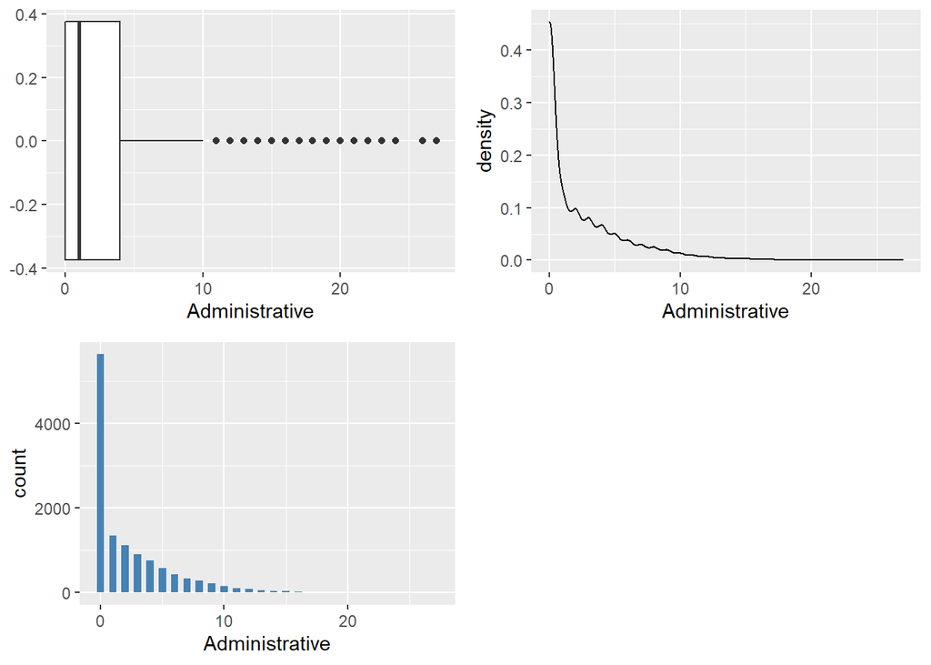

```r
p1 <- ggplot(online_shoppers) + geom_boxplot(aes(Administrative))
p2 <- ggplot(online_shoppers,aes(Administrative)) + geom_bar(fill= "steelblue",width= 0.6)#+ coord_flip()
p3 <- ggplot(online_shoppers) + geom_density(aes(Administrative))



figure <- ggarrange(p1, p3, p2,
                     widths = c(20,20),
                    heights = c(20,20),
                    ncol = 2, nrow = 2)
figure
```

- The mean number of Administrative pages visited by users was 2.34 , with the median value being 1.
- There were outliers in this column. However being that majority of users visited zero such pages , this was not an alarming factor.
- The range of the variable was 27 , with the min value being 0 ,plotting a barplot for this variable we see that in excess of 5,500 users visited zero Administrative pages.
- The column is highly skewed with a value of 1.95 and can be characterized as Leptokurtic with a value of 4.63, this could be attributed to the outliers in the column.

#### ii.Administrative Duration

This column records the amount of time a user spent on an Administrative site.

```r
desc <- describe(online_shoppers$Administrative_Duration)
print(desc)
```

```
##    vars     n  mean     sd median trimmed   mad min     max   range skew
## X1    1 12199 81.68 177.53      9   42.87 13.34  -1 3398.75 3399.75 5.59
##    kurtosis   se
## X1    50.09 1.61
```

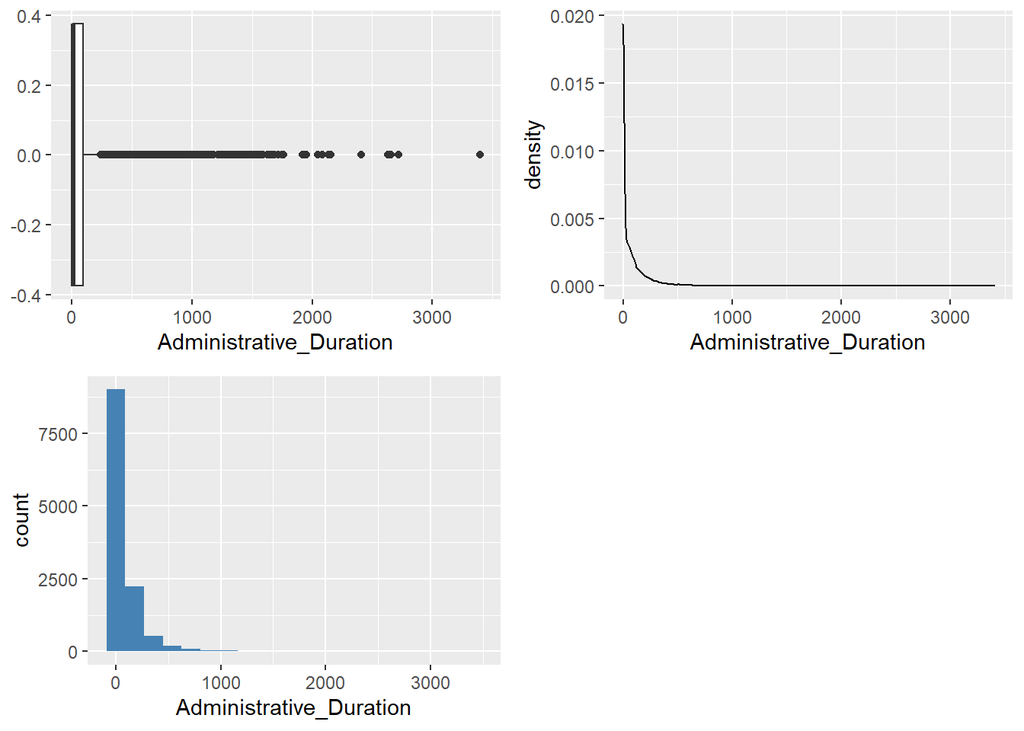

```r
p1 <- ggplot(online_shoppers) + geom_boxplot(aes(Administrative_Duration))
p2 <- ggplot(online_shoppers,aes(Administrative_Duration)) + geom_histogram(fill= "steelblue",bins=20)#+ coord_flip()
p3 <- ggplot(online_shoppers) + geom_density(aes(Administrative_Duration))



figure <- ggarrange(p1, p3, p2,
                     widths = c(20,20),
                    heights = c(20,20),
                    ncol = 2, nrow = 2)
figure
```

- On average users spent 81.68 minutes on Administrative Sites ,with the median amount of time being 9 minutes.
- The variable had very many outliers as seen on the boxplot , however given that there was a high range and many users spent almost almost no time on the site , therefore I did not drop these values.
- The column was highly skewed and leptokurtic , with a values of 5.59 and 50.09 respectively. The Leptokurtic nature of the column can be attributed to the outliers within the column.

#### iii.Informational

This column represents the number of Informational Pages visited by the user.

```r
desc <- describe(online_shoppers$Informational)
print(desc)
```

```
##    vars     n mean   sd median trimmed mad min max range skew kurtosis   se
## X1    1 12199 0.51 1.28      0    0.18   0   0  24    24 4.01    26.64 0.01
```

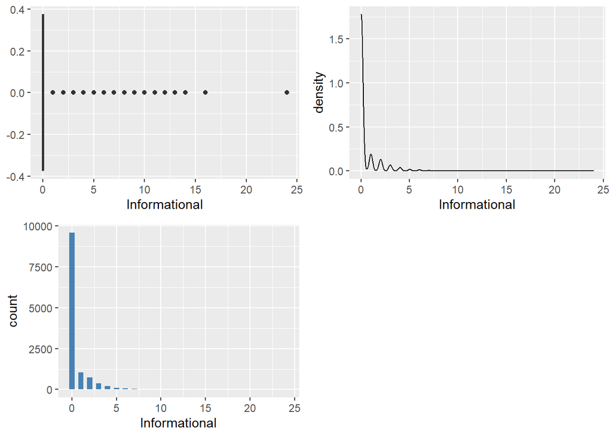

```r
p1 <- ggplot(online_shoppers) + geom_boxplot(aes(Informational))
p2 <- ggplot(online_shoppers,aes(Informational)) + geom_bar(fill= "steelblue",width= 0.6)#+ coord_flip()
p3 <- ggplot(online_shoppers) + geom_density(aes(Informational))



figure <- ggarrange(p1, p3, p2,
                     widths = c(20,20),
                    heights = c(20,20),
                    ncol = 2, nrow = 2)
figure
```

- The average number of Informational Pages frequented by users was 0.51 and the median value was 0.
- From the barplot we can see that almost 10,000 users from a population of over 12,000 visited zero informational pages .
- Therefore this behavious causes the variable to have several outliers and behave in a leptokurtic nature with the kurtosis value being 26.64. The variable is also highly skewed at 4.01.

#### iv.Informational Duration

This column records the amount of time users spent on Informational Sites on the internet.

```r
desc <- describe(online_shoppers$Informational_Duration)
print(desc)
```

```
##    vars     n  mean     sd median trimmed mad min     max   range skew kurtosis
## X1    1 12199 34.84 141.46      0    3.73   0  -1 2549.38 2550.38 7.54    75.45
##      se
## X1 1.28
```

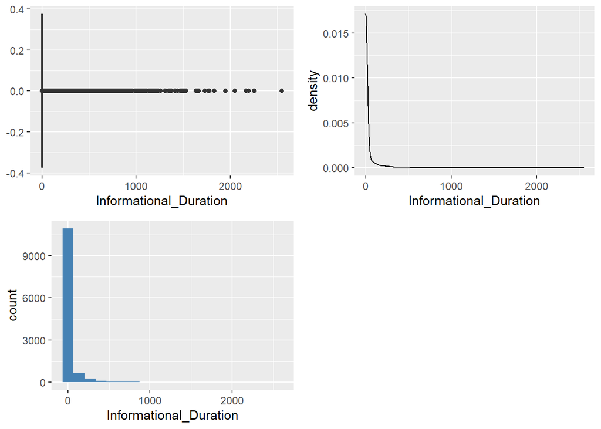

```r
p1 <- ggplot(online_shoppers) + geom_boxplot(aes(Informational_Duration))
p2 <- ggplot(online_shoppers,aes(Informational_Duration)) + geom_histogram(fill= "steelblue",bins=20)#+ coord_flip()
p3 <- ggplot(online_shoppers) + geom_density(aes(Informational_Duration))



figure <- ggarrange(p1, p3, p2,
                     widths = c(20,20),
                    heights = c(20,20),
                    ncol = 2, nrow = 2)
figure
```

- The mean number of hours users spent on Informational Sites was 34.84 while the maximum amount of time spent on Informational sites came in at 2549.38.
- The Variable was highly skewed at 7.54 and leptokurtic in nature with a value of 75.45. This is largely due to the high number of outliers in the dataset.
- From the barplots , over 9,000 users didnot spend any time on Informational Sites.

#### v.ProductRelated

This was the number of ProductRelated sites that users visited.

```r
desc <- describe(online_shoppers$ProductRelated)
print(desc)
```

```
##    vars     n  mean   sd median trimmed   mad min max range skew kurtosis  se
## X1    1 12199 32.06 44.6     18   23.06 19.27   0 705   705 4.33    31.04 0.4
```

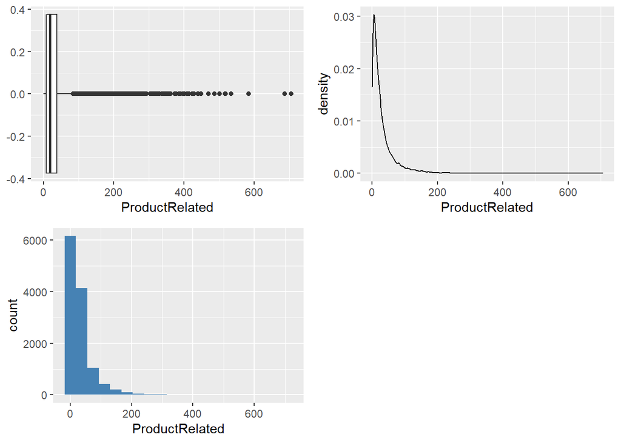

```r
p1 <- ggplot(online_shoppers) + geom_boxplot(aes(ProductRelated))
p2 <- ggplot(online_shoppers,aes(ProductRelated)) + geom_histogram(fill= "steelblue",bins=20)#+ coord_flip()
p3 <- ggplot(online_shoppers) + geom_density(aes(ProductRelated))



figure <- ggarrange(p1, p3, p2,
                     widths = c(20,20),
                    heights = c(20,20),
                    ncol = 2, nrow = 2)
figure
```

#### vi.ProductRelated Duration

This variable represents the amount of time users spent on Product Related Sites

```r
desc <- describe(online_shoppers$ProductRelated_Duration)
print(desc)
```

```
##    vars     n    mean      sd median trimmed    mad min      max    range skew
## X1    1 12199 1207.51 1919.93 609.54  832.36 745.12  -1 63973.52 63974.52 7.25
##    kurtosis    se
## X1   136.57 17.38
```

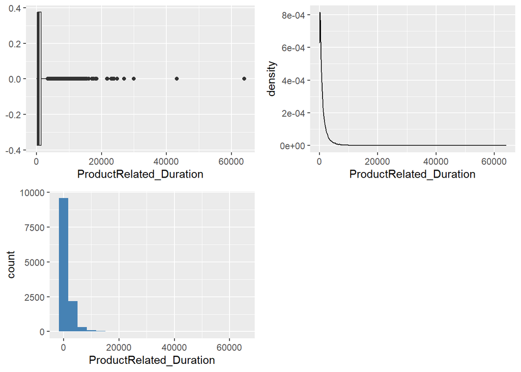

```r
p1 <- ggplot(online_shoppers) + geom_boxplot(aes(ProductRelated_Duration))
p2 <- ggplot(online_shoppers,aes(ProductRelated_Duration)) + geom_histogram(fill= "steelblue",bins=20)#+ coord_flip()
p3 <- ggplot(online_shoppers) + geom_density(aes(ProductRelated_Duration))



figure <- ggarrange(p1, p3, p2,
                     widths = c(20,20),
                    heights = c(20,20),
                    ncol = 2, nrow = 2)
figure
```

- The mean amount of time spent on these sites was on average 1207.51 while the maximum amount of time spent recorded was 63973.52.4
- The Variable is also highly skewed with a value of 7.25 and leptokurtic at 136.57. This is more likely attributed to the outliers in the column.

#### vii.BounceRates

The value of the Bounce Rate feature for a web page refers to the percentage of visitors who enter the site from that page and then leave (bounce) without triggering any other requests to the analytics server during that session.

```r
desc <- describe(online_shoppers$BounceRates)
print(desc)
```

```
##    vars     n mean   sd median trimmed mad min max range skew kurtosis se
## X1    1 12199 0.02 0.05      0    0.01   0   0 0.2   0.2 3.15     9.25  0
```

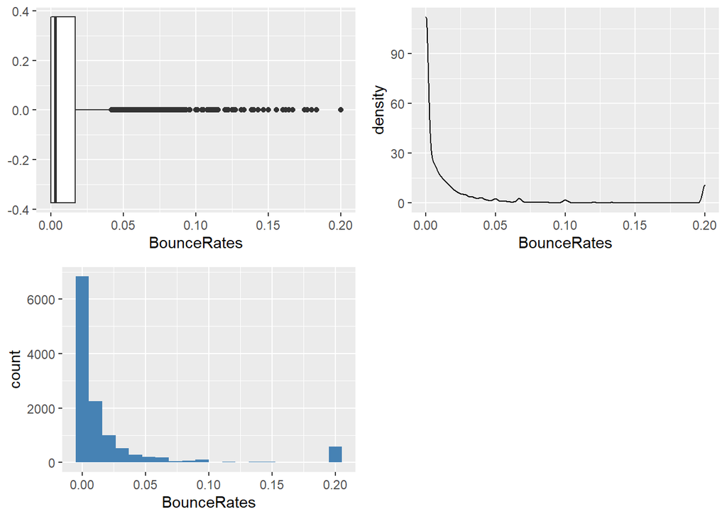

```r
p1 <- ggplot(online_shoppers) + geom_boxplot(aes(BounceRates))
p2 <- ggplot(online_shoppers,aes(BounceRates)) + geom_histogram(fill= "steelblue",bins=20)#+ coord_flip()
p3 <- ggplot(online_shoppers) + geom_density(aes(BounceRates))



figure <- ggarrange(p1, p3, p2,
                     widths = c(20,20),
                    heights = c(20,20),
                    ncol = 2, nrow = 2)
figure
```

- The mean value was 0.02 while the maximum value for the column was 0.2%.
- Similar to the other columns it was highly skewed and leptokurtic and had a high number of outliers.
- From the histogram we can see that majority of the users range between 0 and 0.05% who leave the site without triggering any requests.

#### viii.ExitRates

The value of the Exit Rate feature for a specific web page is calculated as for all pageviews to the page, the percentage that was the last in the session.

```r
desc <- describe(online_shoppers$ExitRates)
print(desc)
```

```
##    vars     n mean   sd median trimmed  mad min max range skew kurtosis se
## X1    1 12199 0.04 0.05   0.03    0.03 0.02   0 0.2   0.2 2.23     4.62  0
```

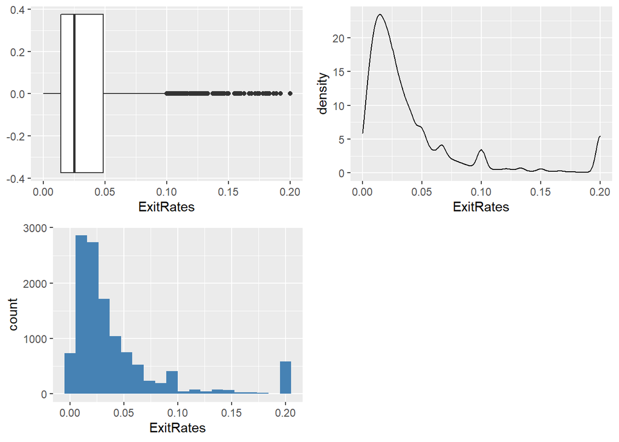

```r
p1 <- ggplot(online_shoppers) + geom_boxplot(aes(ExitRates))
p2 <- ggplot(online_shoppers,aes(ExitRates)) + geom_histogram(fill= "steelblue",bins=20)#+ coord_flip()
p3 <- ggplot(online_shoppers) + geom_density(aes(ExitRates))



figure <- ggarrange(p1, p3, p2,
                     widths = c(20,20),
                    heights = c(20,20),
                    ncol = 2, nrow = 2)
figure
```

- The mean exit rate was 0.04 while the median was 0.03. The column had was highly skewed and leptokurtic coming in at 2.23 and 4.62 respectively.
- The column had many outliers and from the barplot we can see that many of the users ranged between zero and 0.1.

#### ix.PageValues

The Page Value feature represents the average value for a web page that a user visited before completing an e-commerce transaction.

```r
desc <- describe(online_shoppers$PageValues)
print(desc)
```

```
##    vars     n mean    sd median trimmed mad min    max  range skew kurtosis
## X1    1 12199 5.95 18.66      0    1.33   0   0 361.76 361.76 6.35    64.93
##      se
## X1 0.17
```

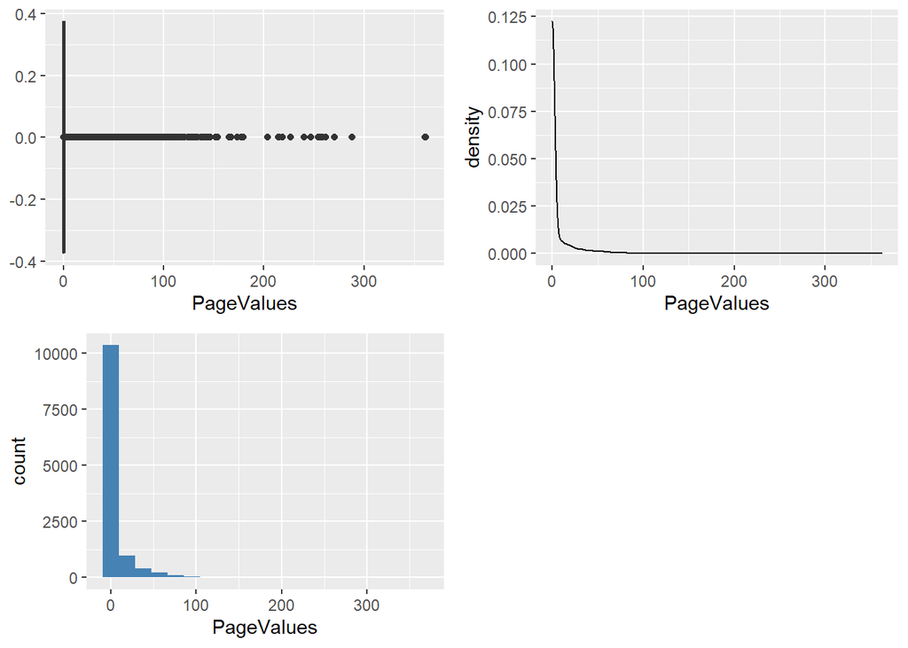

```r
p1 <- ggplot(online_shoppers) + geom_boxplot(aes(PageValues))
p2 <- ggplot(online_shoppers,aes(PageValues)) + geom_histogram(fill= "steelblue",bins=20)#+ coord_flip()
p3 <- ggplot(online_shoppers) + geom_density(aes(PageValues))



figure <- ggarrange(p1, p3, p2,
                     widths = c(20,20),
                    heights = c(20,20),
                    ncol = 2, nrow = 2)
figure
```

- The mean number of times users visited a page before completing a transaction was 5.95 while the median was 0 and the maximum amount was 361.76.
- The variable , similar to those above it was also highly skewed and leptokurtic at 6.35 and 64.93 respectively.

#### x.SpecialValues

The Special Day feature indicates the closeness of the site visiting time to a specific special day (e.g. Mother’s Day, Valentine’s Day) in which the sessions are more likely to be finalized with the transaction. The value of this attribute is determined by considering the dynamics of e-commerce such as the duration between the order date and delivery date.

```r
desc <- describe(online_shoppers$SpecialDay)
print(desc)
```

```
##    vars     n mean  sd median trimmed mad min max range skew kurtosis se
## X1    1 12199 0.06 0.2      0       0   0   0   1     1 3.28     9.78  0
```

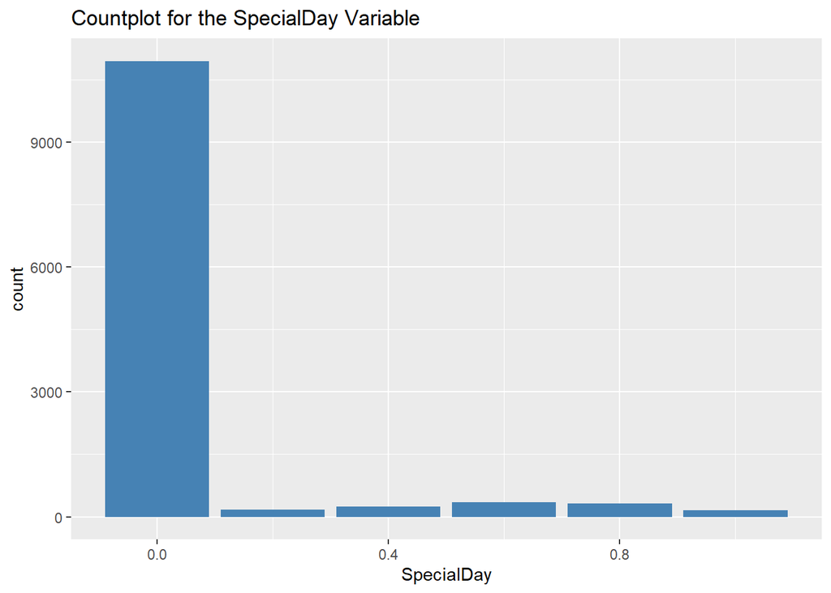

```r
ggplot(online_shoppers, aes(x=SpecialDay)) + geom_bar(fill= "steelblue")+labs(title='Countplot for the SpecialDay Variable')
```

+ Majority of the visits , over 10,000, to the pages occured during dates that were not near Special days.

#### xi.Operating Systems

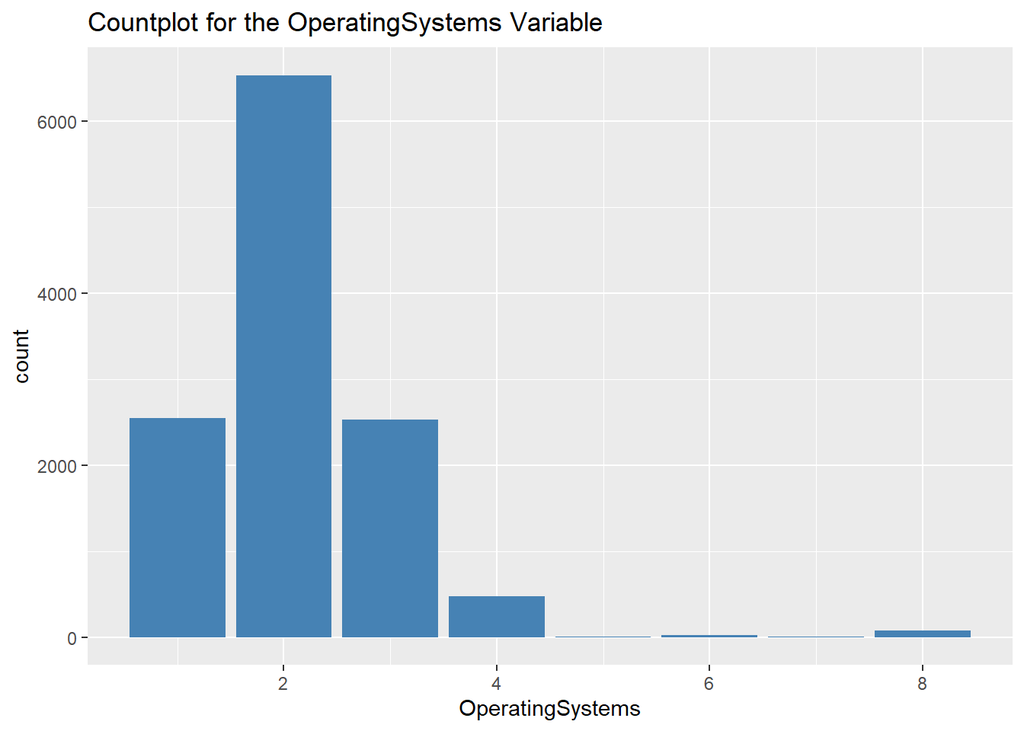

```r
ggplot(online_shoppers, aes(x=OperatingSystems)) + geom_bar(fill= "steelblue")+labs(title='Countplot for the OperatingSystems Variable')
```

- Majority of the users used the Second Operating System , followed ny the third and first OS’s

#### xii.Brower

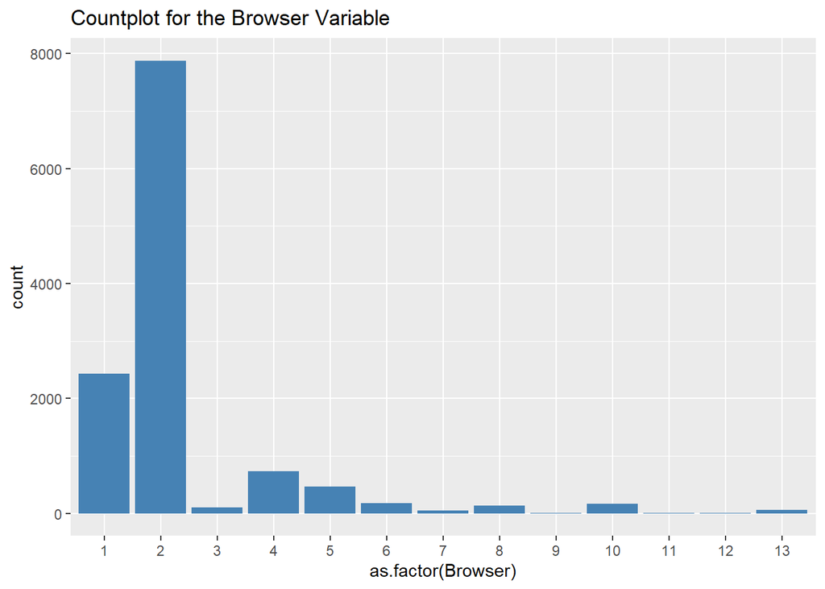

```r
ggplot(online_shoppers, aes(x=as.factor(Browser))) + geom_bar(fill= "steelblue")+labs(title='Countplot for the Browser Variable')
```

- Similarly most of the users used the second of the 13 Web Browsers.

#### xiii.Region

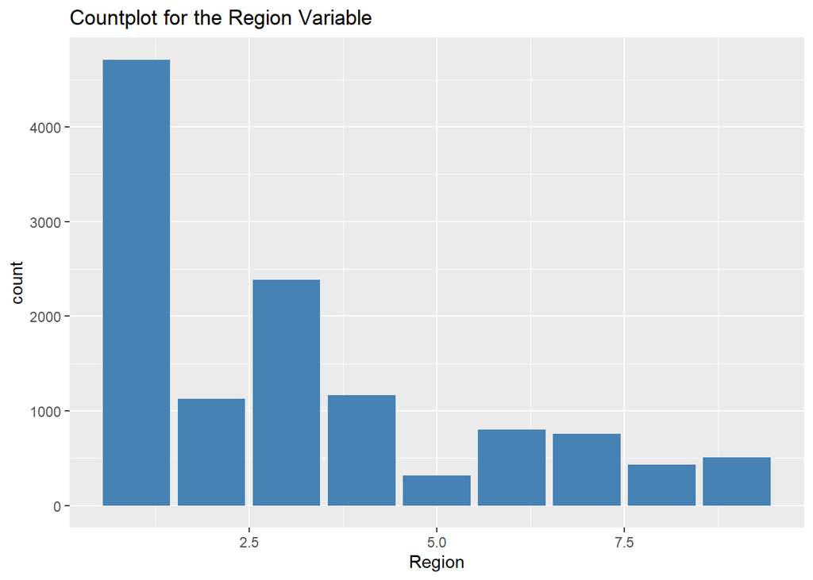

```r
ggplot(online_shoppers, aes(x=Region)) + geom_bar(fill= "steelblue")+labs(title='Countplot for the Region Variable')
```

- Many of the users were from the first region , and then the third region.
- The region with the least users was the fifth region.

#### xiv.TrafficType

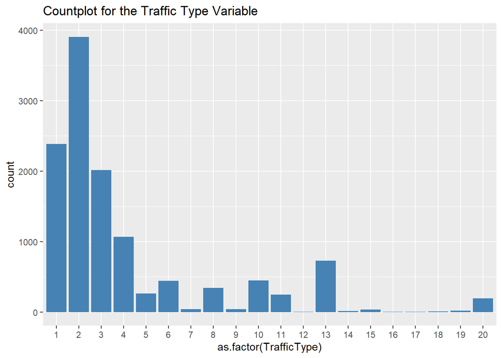

```r
ggplot(online_shoppers, aes(x=as.factor(TrafficType))) + geom_bar(fill= "steelblue")+labs(title='Countplot for the Traffic Type Variable')
```

- The second type of traffic was the most popular with almost 4,000 users whereas the 12th , 16th and 17th had next to no users.

#### xv.Month

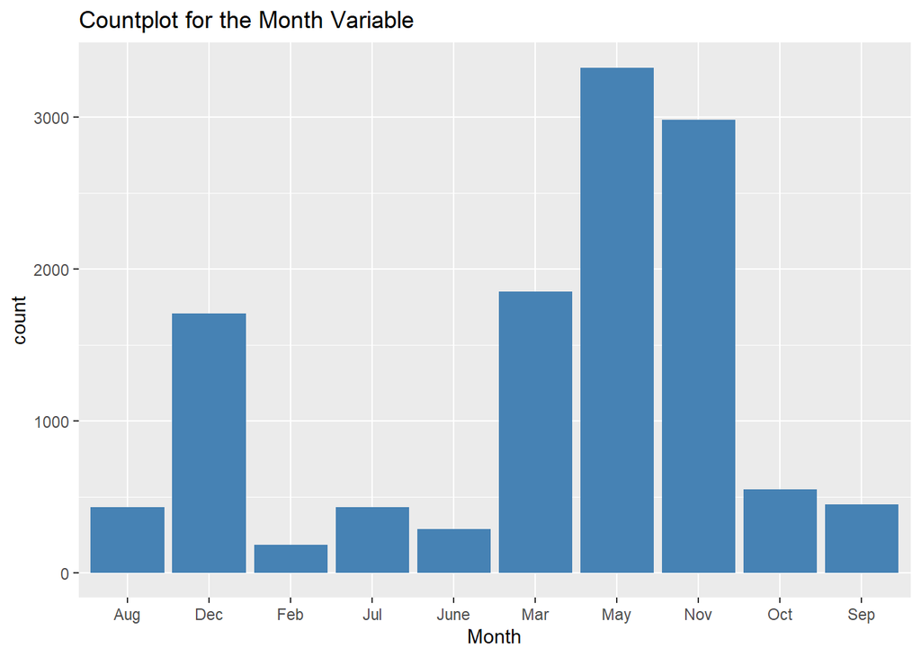

```r
ggplot(online_shoppers, aes(x=Month)) + geom_bar(fill= "steelblue")+labs(title='Countplot for the Month Variable')
```

- The most popular months of the year were May , November ,March and December in that order.
- The least popular months of the year were Feb, September , June ,July and August in no particular order.

#### xvi.VisitorType

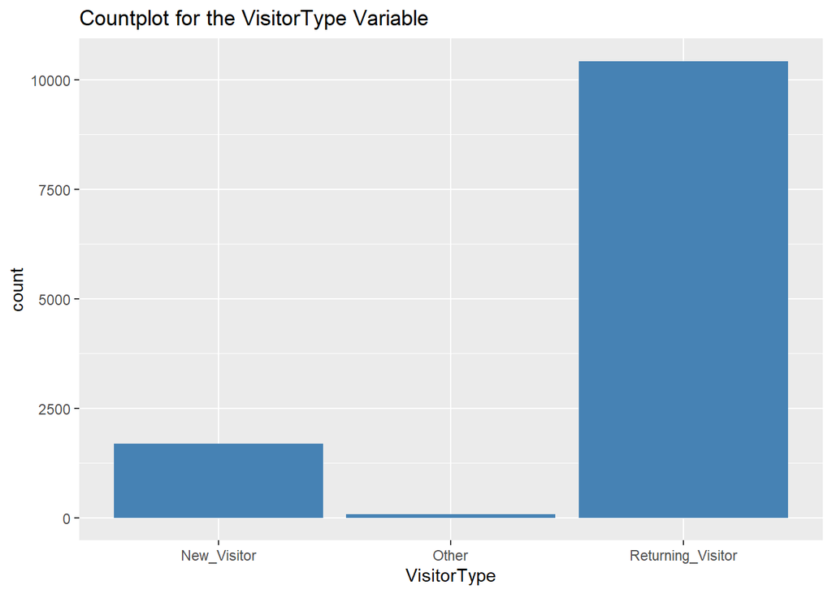

```r
ggplot(online_shoppers, aes(x=VisitorType)) + geom_bar(fill= "steelblue")+labs(title='Countplot for the VisitorType Variable')
```

- Over 10,000 users visiting particular sites were returning visitors while new visitors averaged at 2,000 and others were almost zero.

#### xvii.Weekend

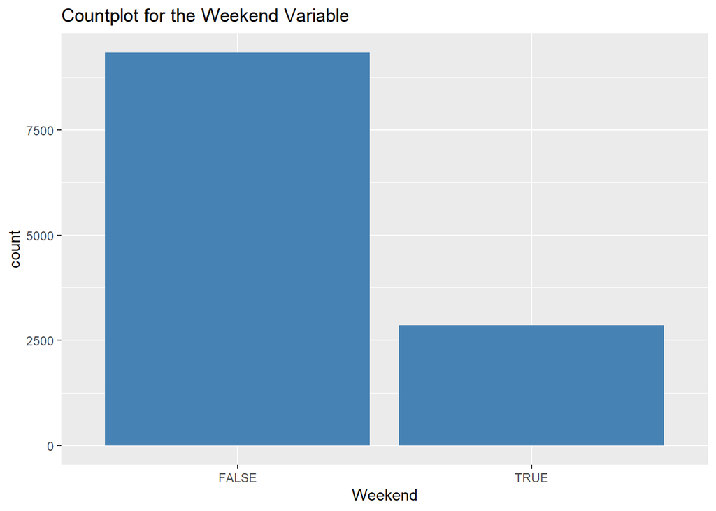

```r
ggplot(online_shoppers, aes(x=Weekend)) + geom_bar(fill= "steelblue")+ labs(title='Countplot for the Weekend Variable')
```

There was more activity on the sites on Weekdays , compared to weekdays.

#### xviii.Revenue

This was a Logical Variable , showing whether or not the site made money from a user

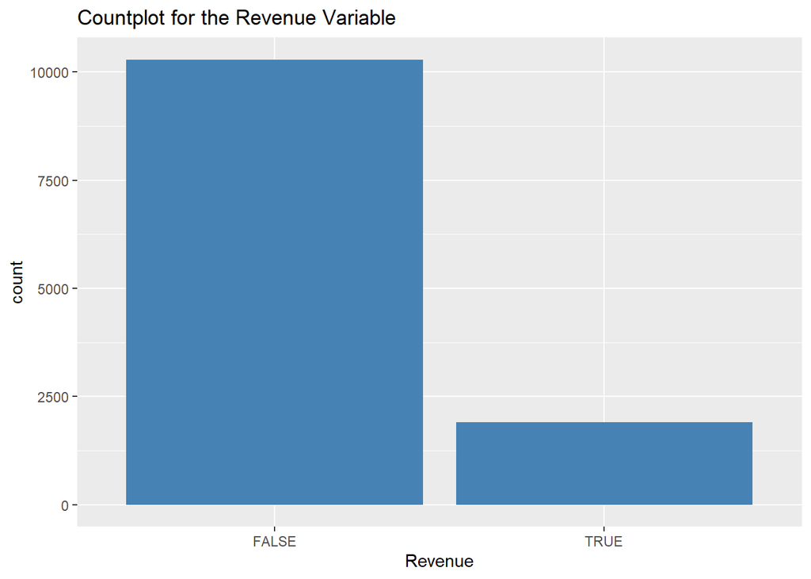

```r
ggplot(online_shoppers, aes(x=Revenue)) + geom_bar(fill= "steelblue")+labs(title='Countplot for the Revenue Variable')
```

The site did not make any Revenue most of the time , over 10,000 , as seen in the countplot.

## 5.2.Bivariate Data Analysis

I then carried out my bivariate analysis , comparing many of the variables in the dataset with each other and also with the Target, Revenue , Variable.

#### i.Revenue Distribution by Region

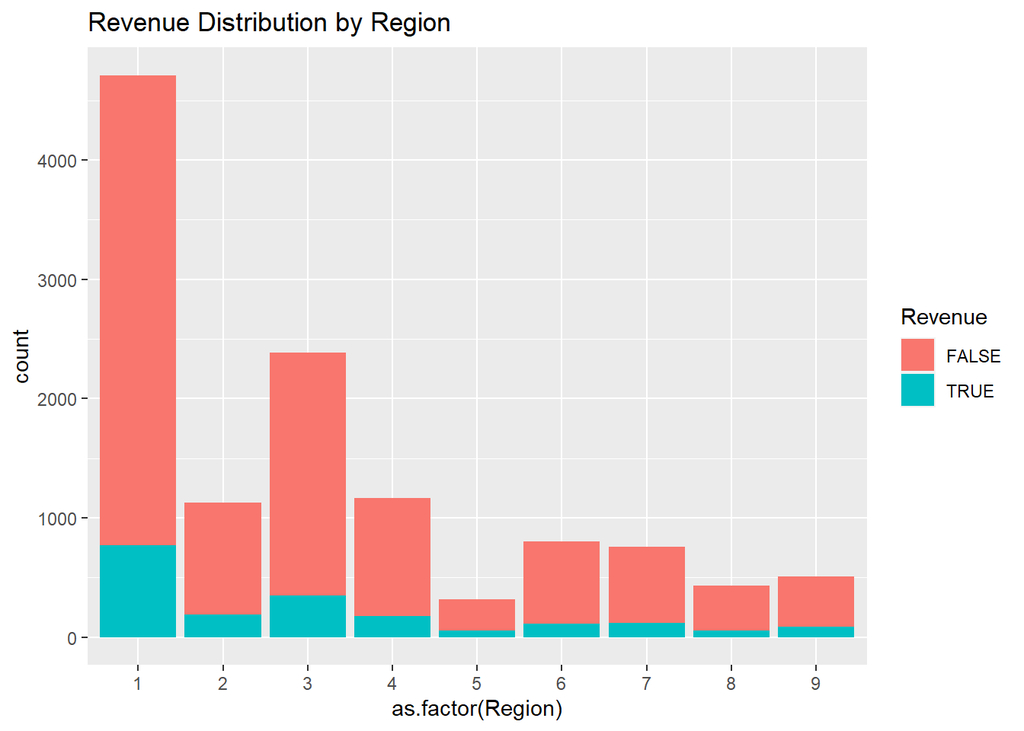

```r
ggplot(online_shoppers, aes(x=as.factor(Region))) + geom_bar(aes(fill= `Revenue`)) + labs(title='Revenue Distribution by Region')
```

The first region with the highest demographic of users brings in the highest revenue to the site .

#### ii. Revenue Distribution by Special Day Variable

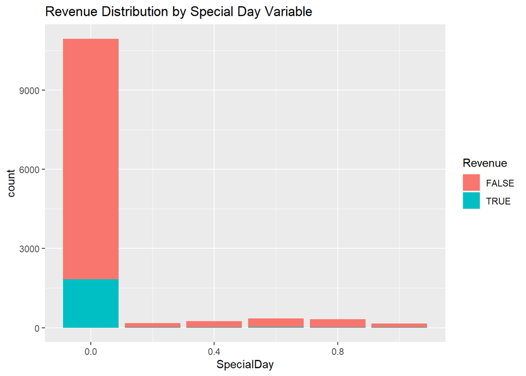

```r
ggplot(online_shoppers, aes(x=SpecialDay)) + geom_bar(aes(fill= `Revenue`))+labs(title='Revenue Distribution by Special Day Variable')
```

Most of the revenue made on the site is made on days that are not associated with special days.

#### iii. Revenue Distribution by Traffic Type Variable

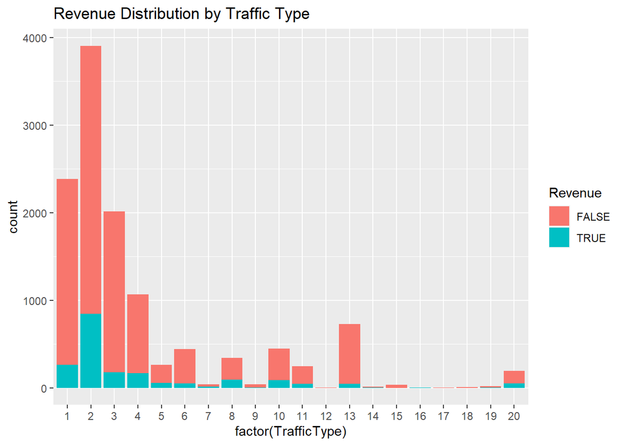

```r
ggplot(online_shoppers, aes(x=factor(TrafficType))) + geom_bar(aes(fill= `Revenue`))+labs(title='Revenue Distribution by Traffic Type ')
```

The second traffic type , with approximately 4,000 users also brings about the highest revenue.

#### iv. Revenue Distribution by Month

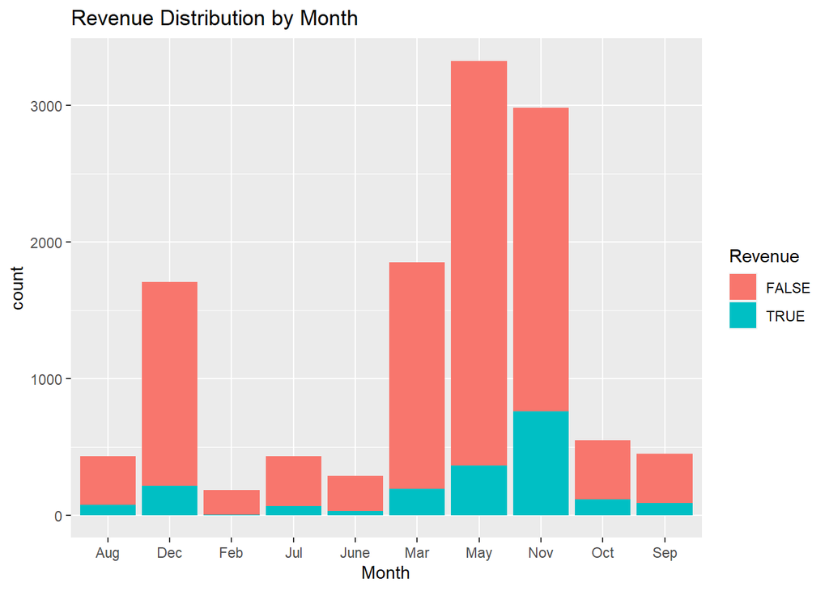

```r
ggplot(online_shoppers, aes(x=Month )) + geom_bar(aes(fill= `Revenue`))+labs(title='Revenue Distribution by Month')
```

The highest revenue is made in the month of November , the second busiest month of the year. This may be due to the fact that many people are making purchases for the holiday season.

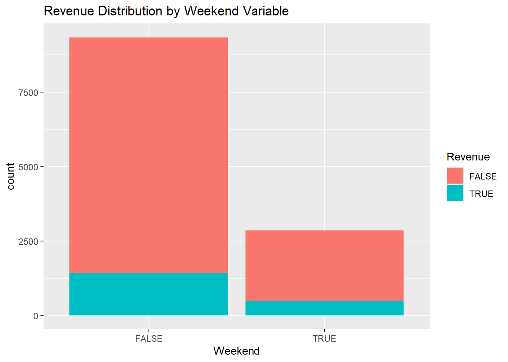

```r
ggplot(online_shoppers, aes(x=Weekend)) + geom_bar(aes(fill=Revenue))+labs(title='Revenue Distribution by Weekend Variable')
```

Given that many users visit these sites on weekdays as compared to weekends then we can see that much of the revenue is made on Weekdays.

#### vi.Revenue Distribution by Visitor Type

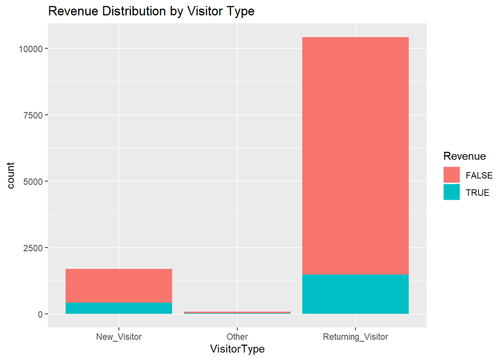

```r
ggplot(online_shoppers, aes(x=VisitorType)) + geom_bar(aes(fill=Revenue))+labs(title='Revenue Distribution by Visitor Type')
```

Most of the revenue , can be seen to have come from the Returning Visitors of the site , however given that they make up a large demographic of the users this was expected.

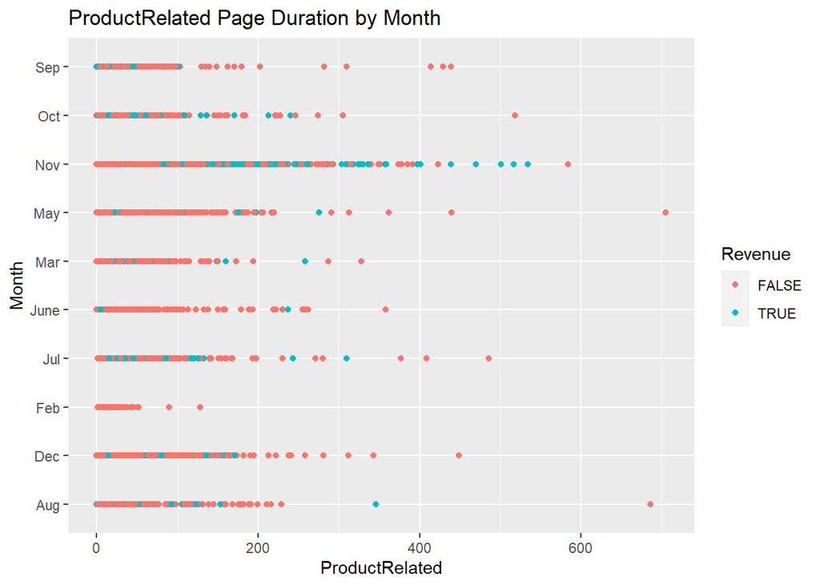

```r
ggplot(online_shoppers, aes(y=Month ,x = ProductRelated )) + geom_point(aes(colour= `Revenue`))+labs(title='ProductRelated Page Duration by Month')
```

#### viii.Informational Page Duration by Month

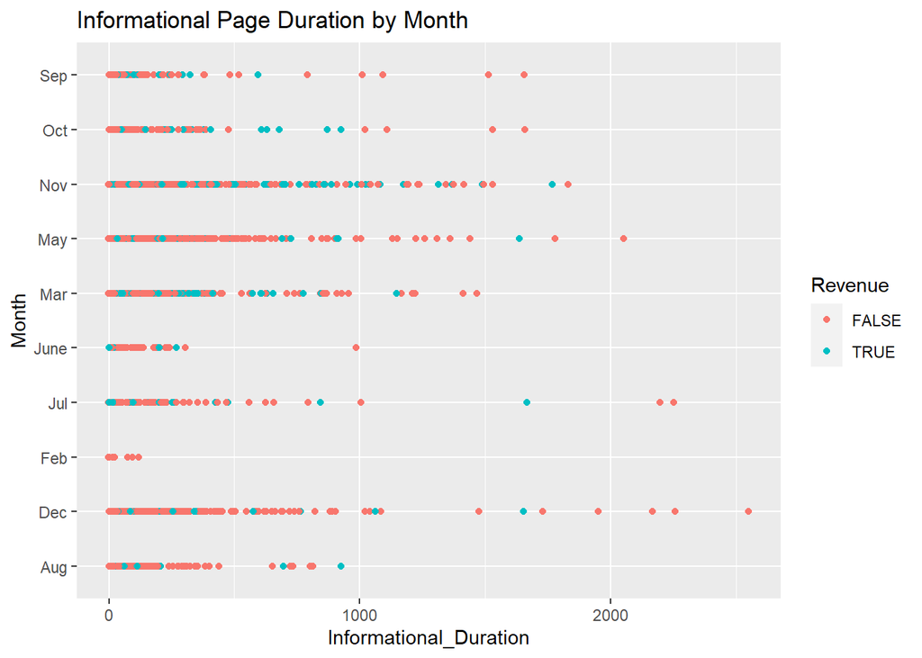

```r
ggplot(online_shoppers, aes(y=Month ,
                            x = Informational_Duration )) + geom_point(aes(colour= `Revenue`))+labs(title='Informational Page Duration by Month')
```

Similarly many users can be seen to spend alot of time in the Informational Page in the month of November. May and December can also be seen to bring about similar numbers in terms of users on these pages and the amount of time theu spend.

#### ix.Administrative Page Duration by Month

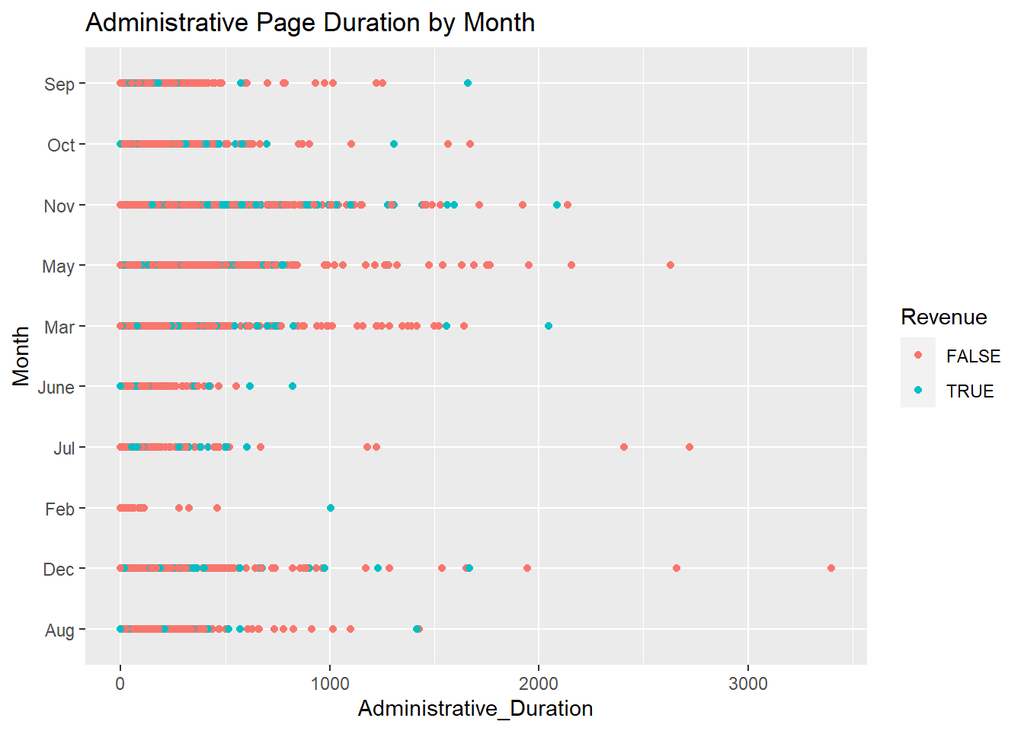

```r
ggplot(online_shoppers, aes(y=Month,
                            x = Administrative_Duration )) + geom_point(aes(colour= `Revenue`))+labs(title='Administrative Page Duration by Month')
```

Users can also be seen to spend high amount of time on Administrative pages in November ,March and May. February has the least amount of traffic to these pages and the amount of revenue in this month can be seen to be next to none.

#### x.Exit rates by Month

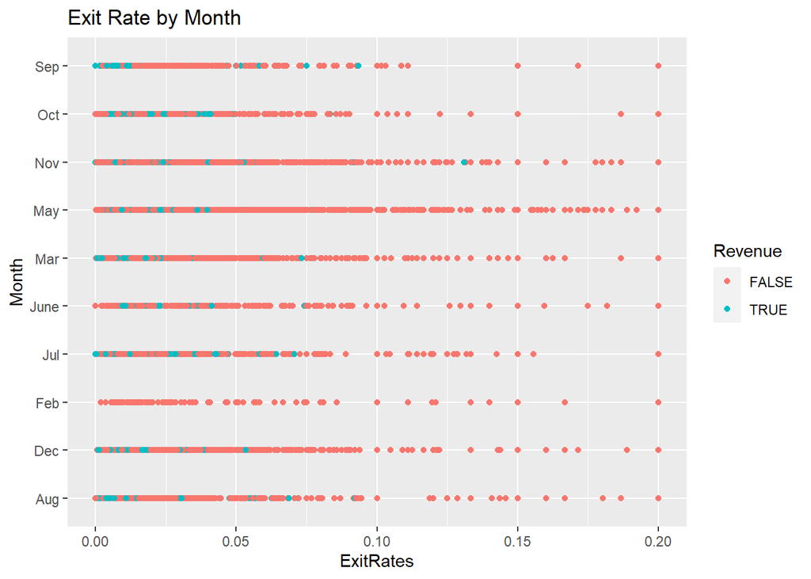

```r
ggplot(online_shoppers, aes(y=Month,
                            x = ExitRates )) + geom_point(aes(colour= `Revenue`))+labs(title='Exit Rate by Month')
```

The exit rates of the sites , can be seen to be highest in May , followed by November.

#### xi. ExitRate against Bounce Rate

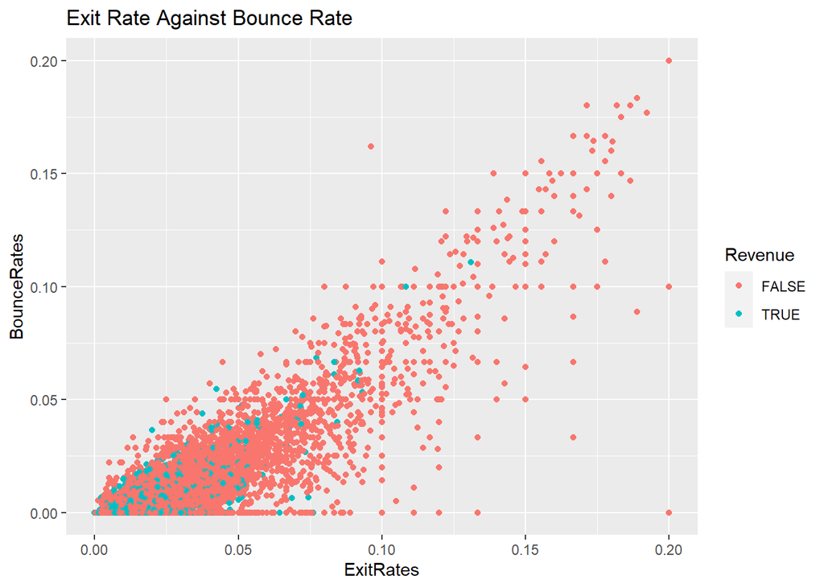

```r
ggplot(online_shoppers, aes(x=ExitRates,
                            y = BounceRates )) + geom_point(aes(colour= `Revenue`))+labs(title='Exit Rate Against Bounce Rate')
```

Plotting a scatter plot of Bounce Rates against Exit rates and we can see that there seems to be a positive correlation between the two variables.

Users with lower bounce rates and exit rates seem to be the ones bringing in the revenue as these variables increase the revenue comes close to null.

### Feature Engineering

After plotting the relevant visualizations , I then encoded the VisitorType and Weekend variables. Given that the Revenue variable was the label , I dropped it as unsupervised learning does not require labels.

```r
# I encoded the Month,VisitorType and Weekend Variabls using one-hot encoding

library(caret)
dat <- select(online_shoppers,c(Month,VisitorType,Weekend,Revenue))
dmy <- dummyVars(" ~ .", data = dat, fullRank = T)
dat_transformed <- data.frame(predict(dmy, newdata = dat))

glimpse(dat_transformed)
```

```
## Rows: 12,199
## Columns: 13
## $ MonthDec                     <dbl> 0, 0, 0, 0, 0, 0, 0, 0, 0, 0, 0, 0, 0,...
## $ MonthFeb                     <dbl> 1, 1, 1, 1, 1, 1, 1, 1, 1, 1, 1, 1, 1,...
## $ MonthJul                     <dbl> 0, 0, 0, 0, 0, 0, 0, 0, 0, 0, 0, 0, 0,...
## $ MonthJune                    <dbl> 0, 0, 0, 0, 0, 0, 0, 0, 0, 0, 0, 0, 0,...
## $ MonthMar                     <dbl> 0, 0, 0, 0, 0, 0, 0, 0, 0, 0, 0, 0, 0,...
## $ MonthMay                     <dbl> 0, 0, 0, 0, 0, 0, 0, 0, 0, 0, 0, 0, 0,...
## $ MonthNov                     <dbl> 0, 0, 0, 0, 0, 0, 0, 0, 0, 0, 0, 0, 0,...
## $ MonthOct                     <dbl> 0, 0, 0, 0, 0, 0, 0, 0, 0, 0, 0, 0, 0,...
## $ MonthSep                     <dbl> 0, 0, 0, 0, 0, 0, 0, 0, 0, 0, 0, 0, 0,...
## $ VisitorTypeOther             <dbl> 0, 0, 0, 0, 0, 0, 0, 0, 0, 0, 0, 0, 0,...
## $ VisitorTypeReturning_Visitor <dbl> 1, 1, 1, 1, 1, 1, 1, 1, 1, 1, 1, 1, 1,...
## $ WeekendTRUE                  <dbl> 0, 0, 0, 0, 1, 0, 0, 1, 0, 0, 0, 0, 0,...
## $ RevenueTRUE                  <dbl> 0, 0, 0, 0, 0, 0, 0, 0, 0, 0, 0, 0, 0,...
```

I then dropped the `Revenue , Month , VisitorType and Weekend` columns from the dataset.

```r
# Dropping the Revenue Variable, Month VisitorType and Weekend columns after encoding
online_shoppers <- select(online_shoppers , c(-Revenue,-Month,-VisitorType,-Weekend))
dim(online_shoppers)
```

```
## [1] 12199    14
```

I then used the cbind() function to add the encoded variables into my dataset.

```r
# I then used the cbind() function to merge my encoded columns with the other columns in my dataset
online_shoppers <- cbind(online_shoppers,dat_transformed)
dim(online_shoppers)
```

```
## [1] 12199    27
```

```r
glimpse(online_shoppers)
```

```
## Rows: 12,199
## Columns: 27
## $ Administrative               <dbl> 0, 0, 0, 0, 0, 0, 0, 1, 0, 0, 0, 0, 0,...
## $ Administrative_Duration      <dbl> 0, 0, -1, 0, 0, 0, -1, -1, 0, 0, 0, 0,...
## $ Informational                <dbl> 0, 0, 0, 0, 0, 0, 0, 0, 0, 0, 0, 0, 0,...
## $ Informational_Duration       <dbl> 0, 0, -1, 0, 0, 0, -1, -1, 0, 0, 0, 0,...
## $ ProductRelated               <dbl> 1, 2, 1, 2, 10, 19, 1, 1, 2, 3, 3, 16,...
## $ ProductRelated_Duration      <dbl> 0.000000, 64.000000, -1.000000, 2.6666...
## $ BounceRates                  <dbl> 0.200000000, 0.000000000, 0.200000000,...
## $ ExitRates                    <dbl> 0.200000000, 0.100000000, 0.200000000,...
## $ PageValues                   <dbl> 0, 0, 0, 0, 0, 0, 0, 0, 0, 0, 0, 0, 0,...
## $ SpecialDay                   <dbl> 0.0, 0.0, 0.0, 0.0, 0.0, 0.0, 0.4, 0.0...
## $ OperatingSystems             <dbl> 1, 2, 4, 3, 3, 2, 2, 1, 2, 2, 1, 1, 1,...
## $ Browser                      <dbl> 1, 2, 1, 2, 3, 2, 4, 2, 2, 4, 1, 1, 1,...
## $ Region                       <dbl> 1, 1, 9, 2, 1, 1, 3, 1, 2, 1, 3, 4, 1,...
## $ TrafficType                  <dbl> 1, 2, 3, 4, 4, 3, 3, 5, 3, 2, 3, 3, 3,...
## $ MonthDec                     <dbl> 0, 0, 0, 0, 0, 0, 0, 0, 0, 0, 0, 0, 0,...
## $ MonthFeb                     <dbl> 1, 1, 1, 1, 1, 1, 1, 1, 1, 1, 1, 1, 1,...
## $ MonthJul                     <dbl> 0, 0, 0, 0, 0, 0, 0, 0, 0, 0, 0, 0, 0,...
## $ MonthJune                    <dbl> 0, 0, 0, 0, 0, 0, 0, 0, 0, 0, 0, 0, 0,...
## $ MonthMar                     <dbl> 0, 0, 0, 0, 0, 0, 0, 0, 0, 0, 0, 0, 0,...
## $ MonthMay                     <dbl> 0, 0, 0, 0, 0, 0, 0, 0, 0, 0, 0, 0, 0,...
## $ MonthNov                     <dbl> 0, 0, 0, 0, 0, 0, 0, 0, 0, 0, 0, 0, 0,...
## $ MonthOct                     <dbl> 0, 0, 0, 0, 0, 0, 0, 0, 0, 0, 0, 0, 0,...
## $ MonthSep                     <dbl> 0, 0, 0, 0, 0, 0, 0, 0, 0, 0, 0, 0, 0,...
## $ VisitorTypeOther             <dbl> 0, 0, 0, 0, 0, 0, 0, 0, 0, 0, 0, 0, 0,...
## $ VisitorTypeReturning_Visitor <dbl> 1, 1, 1, 1, 1, 1, 1, 1, 1, 1, 1, 1, 1,...
## $ WeekendTRUE                  <dbl> 0, 0, 0, 0, 1, 0, 0, 1, 0, 0, 0, 0, 0,...
## $ RevenueTRUE                  <dbl> 0, 0, 0, 0, 0, 0, 0, 0, 0, 0, 0, 0, 0,...
```

```r
online_shoppers_hc <- online_shoppers
dim(online_shoppers_hc)
```

```
## [1] 12199    27
```

I plotted the Correlation matrix of the variables in the dataset and made the following observations:

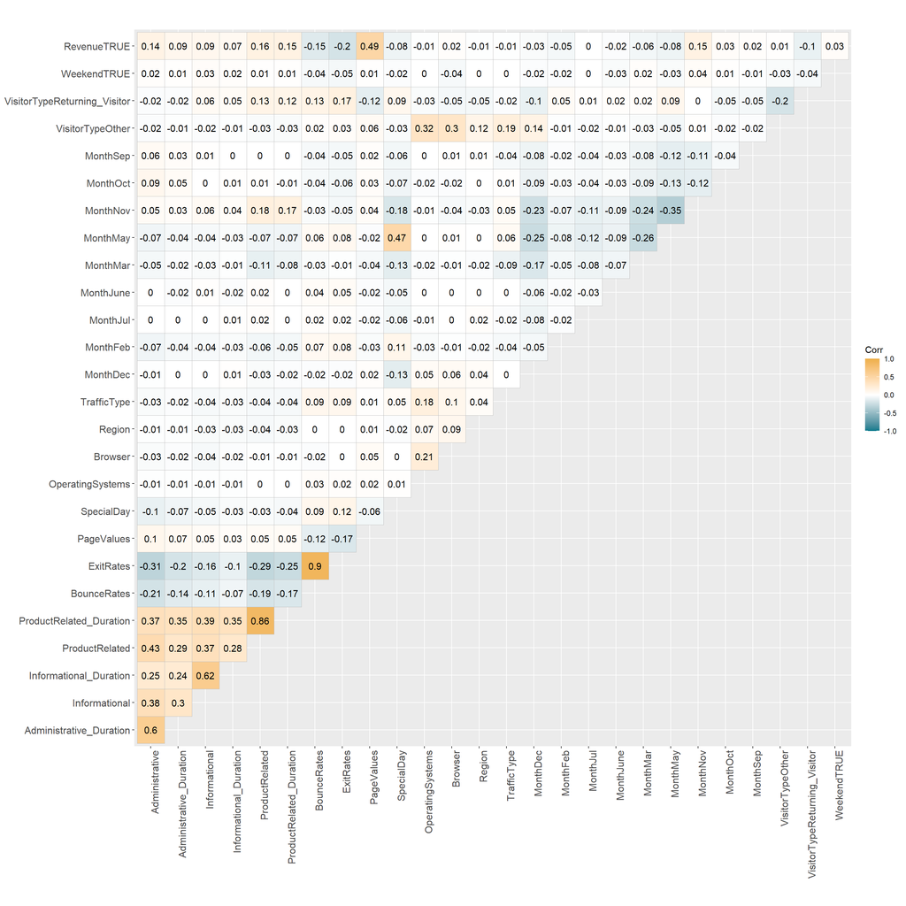

```r
# Plotting the Correlation Heatmap
library(ggcorrplot)
ggcorrplot(cor(online_shoppers), hc.order = F,type =
"upper", lab = T ,
  ggtheme = ggplot2::theme_gray,
  colors = c("#00798c", "white", "#edae49"),
  tl.srt = 90)
```

The RevenueTrue column was correlated with the PageValues variable at 0.49 . There was also a strong positive correlation between the SpecialDay variable and the Month May.

### Summary

- From my EDA I noted that many of the variables in the dataset were heavily skewed and leptokurtic , the reason for this may have been that there were very many outliers in this dataset.
- The cause of these outliers was that many of the users didnot visit some of the pages , for example many users did not visit any informational pages , thus any inputs that were higher than zero were more likely recorded as outliers. For this reason I didn’t drop any of them as they were accurate representations.

# 6. Implementing the Solution

I want to characterize the behaviour of the customers of the Kira brand based on the information at hand.I applied unsupervised learning and I used two clustering techniques i.e:

```
` Hierarchical Clustering`

` K-Means Clustering `
```

## 6.1. K-Means Clustering

Before building my model I normalized the dataset by applying a normalization function.

```r
online_shoppers <- select(online_shoppers , -RevenueTRUE)
dim(online_shoppers)
```

```
## [1] 12199    26
```

```r
# Creating a Normalizing Function
normalize <- function(x){
  return ((x-min(x)) / (max(x)-min(x)))
}

# Applying the Normalization function to the data
online_shoppers<- normalize(online_shoppers)
head(online_shoppers)
```

```
##   Administrative Administrative_Duration Informational Informational_Duration
## 1   1.563122e-05            1.563122e-05  1.563122e-05           1.563122e-05
## 2   1.563122e-05            1.563122e-05  1.563122e-05           1.563122e-05
## 3   1.563122e-05            0.000000e+00  1.563122e-05           0.000000e+00
## 4   1.563122e-05            1.563122e-05  1.563122e-05           1.563122e-05
## 5   1.563122e-05            1.563122e-05  1.563122e-05           1.563122e-05
## 6   1.563122e-05            1.563122e-05  1.563122e-05           1.563122e-05
##   ProductRelated ProductRelated_Duration  BounceRates    ExitRates   PageValues
## 1   3.126245e-05            1.563122e-05 1.875747e-05 1.875747e-05 1.563122e-05
## 2   4.689367e-05            1.016029e-03 1.563122e-05 1.719434e-05 1.563122e-05
## 3   3.126245e-05            0.000000e+00 1.875747e-05 1.875747e-05 1.563122e-05
## 4   4.689367e-05            5.731448e-05 1.641278e-05 1.781959e-05 1.563122e-05
## 5   1.719434e-04            9.824223e-03 1.594385e-05 1.641278e-05 1.563122e-05
## 6   3.126245e-04            2.426226e-03 1.587803e-05 1.601515e-05 1.563122e-05
##     SpecialDay OperatingSystems      Browser       Region  TrafficType
```

[output cut: 27 more lines]

```r
memory.limit(24000)
```

```
## [1] 24000
```

#### 6.1.1.Finding the Optimal K

##### 6.1.1.The Elbow Method

```r
#Elbow Method for finding the optimal number of clusters
set.seed(1123)
# Compute and plot wss for k = 2 to k = 15.
k.max <- 15
data <- online_shoppers
wss <- sapply(1:k.max,
              function(k){kmeans(data, k, nstart=50,iter.max = 1000 , algorithm="Lloyd" )$tot.withinss})
wss
```

```
##  [1] 11.1467701  5.2449415  3.2181497  2.2584201  1.4683057  1.1604253
##  [7]  0.9693224  0.8543638  0.7680412  0.7237357  0.4004511  0.3817133
## [13]  0.3486827  0.3268700  0.3187259
```

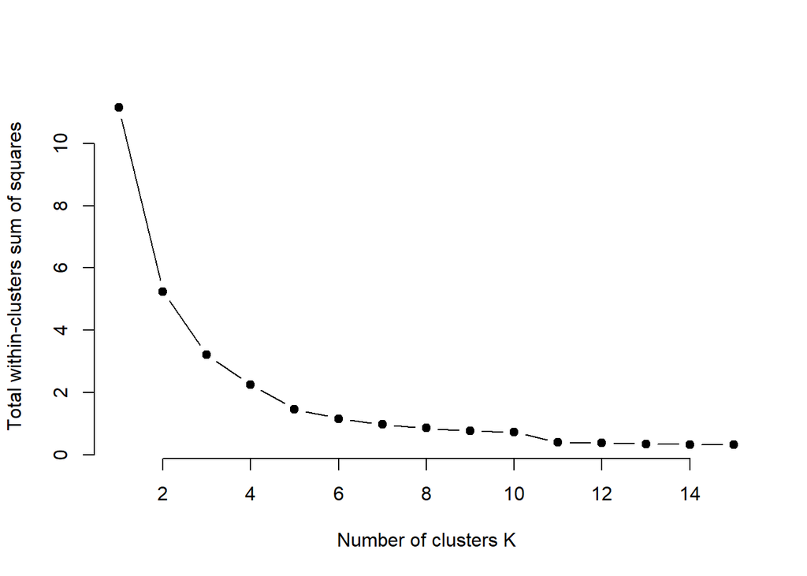

```r
plot(1:k.max, wss,
     type="b", pch = 19, frame = FALSE,
     xlab="Number of clusters K",
     ylab="Total within-clusters sum of squares")
```